# Class 6 | Lab 5

Spring 2022

## Class 6 Lab - Working with Map Projections

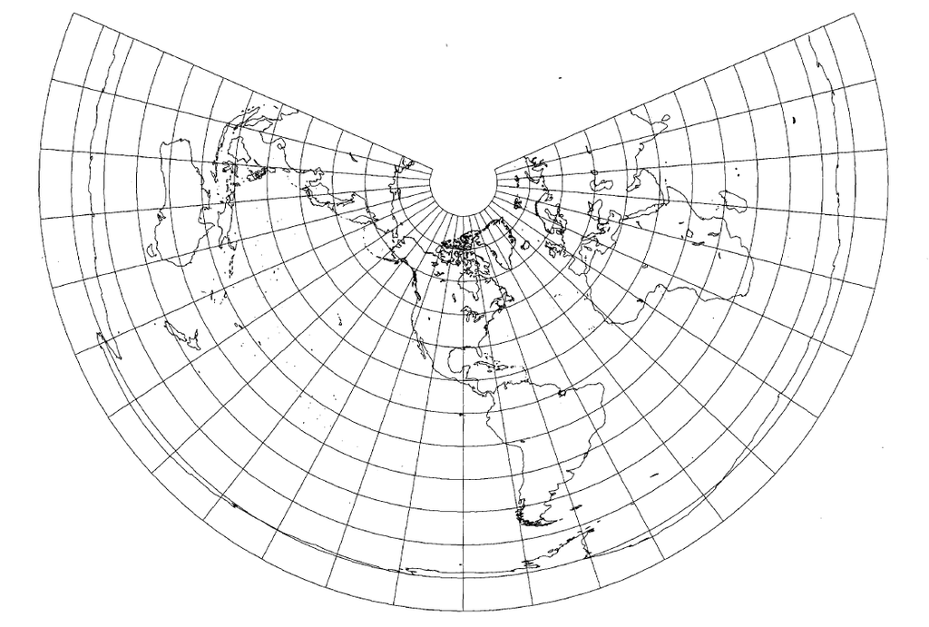

*Source: https://pubs.er.usgs.gov/publication/pp1453* Equidistant Conic Projection (equally spaced parallels - often used for small countries in atlases)

### Concepts & Themes:

This week’s lab will feature exploration of the following:

1. Role of projections in Small Scale vs Large Scale mapping tasks
2. ‘On-the-fly’ transformation capacities in QGIS
3. [EPSG Codes](http://www.epsg-registry.org/)
4. `Proj.4` - [LINK](http://download.osgeo.org/proj/OF90-284.pdf)

### Lab 6 Links:

During this week’s lab, utilize the following PDF (Discover QGIS 3.x) and zipped data folder for conducting **Tasks 2-4**:

- [Texbook PDF Guide](https://gislabdata.s3.us-east-2.amazonaws.com/c6.qgis/task1_4.UTM.pdf)
- [**Tasks 2-4** Zipped Data download](https://www.dropbox.com/s/z1zdn8hmp0n70ed/c6.lab_and_assignment_data.zip?dl=1)
- **Task 1** Exploring Coordinate Systems and Map Projections (This will be conducted during lecture demo, not lab).
- **Task 2** Exploring World Map Projections (Lab)
- **Task 3** Exploring National Map Projections & Defining a Custom CRS (Lab)
- **Task 4** Exploring State Map Projections & Layer Reprojection (Lab)
- **Task 5** Task 5 - Exploring the Universal Transverse Mercator (UTM) Coordinate System (This will be part of the Class 6 Assignment, not lab).

### Lab Steps:

- **To start**, open `World View.qgs` from the the [**Tasks 2-4** Zipped Data download](https://www.dropbox.com/s/z1zdn8hmp0n70ed/c6.lab_and_assignment_data.zip?dl=1).
- Working through **Task 2**, focus on the following concepts:
  - Preservation of the area property (equal area) of `World Eckert IV EPSG:54012`
- Working through **Task 3**, focus on the following concepts:
  - Creating a Custom Coordinate Reference System for `World Eckert IV EPSG:54012` focused on USA, not world.
  - mapping with suitable projections for mid-scales (countries & regions)
  - CRS parameters:
    - False easting
    - False northing
    - Central meridian
    - Standard parallel(s)
    - Latitude of Origin
  - Concepts related to map projections:
    - Spheroid
    - Datum
    - Coordinate Units
- Working through **Task 4**, focus on the following concepts:
  - The State Plane Coordinate System (SPCS)
    - 120 zones exclusive to the USA
    - Highly accurate, ideal for mapping urban areas
    - Originally developed in the 1930’s
  - Layers that are added ‘first’ to a `.qgs` project ‘set’ the project’s coordinate system
  - OTF vs setting a layer’s projection by `save as` with projected added. Note that an OTF projection is set to the `.qgs` project file, and not permanently stored at the layer level. To set permanetly for a layer, use `save as` option.
  - Set `CRS` behaviors via `Settings > Options > CRS`

### Further Reference:

- [CRS overview applicable to QGIS using PROJ.4](https://www.nceas.ucsb.edu/~frazier/RSpatialGuides/OverviewCoordinateReferenceSystems.pdf)
- [PROJ.4 parameters](http://proj4.org/parameters.html)